# Advanced Neotoma for Fun and Profit

Simon Goring

October 6, 2016

# 1 What we’ll learn

This document is intended to act as a more complete vignette of the `neotoma` package’s functionality. I’ll show some functions & behaviour that’s not neccessarily shown in the examples or the [*Open Quaternary* paper](http://www.openquaternary.com/articles/10.5334/oq.ab/). Some of these examples are pretty straightforward, some are a bit more complicated. I’ve made an effort to clearly comment code, but welcome any suggestions. If you do have bug fixes, comments, or requests for additional examples, please let me know at goring@wisc.edu or through the issues for [my website’s GitHub repository](http://github.com/SimonGoring/simongoring.github.io/issues).

# 2 Data Exploration Made Easy

It’s a bit of a pain to download lots of records and then visualize them in R, or at least, it had been. In building the package I wanted to try to limit the need to install lots of other packages, so the basic `plot()` method isn’t all that helpful:

```r
library(neotoma)

# I'll try as much as I can to use the PACKAGE::FUNCTION() convention, although
# you don't need to use it.  Since this is a learning document I think it help
# make it a bit more explicit where these calls are coming from.

all_wi <- neotoma::get_dataset(gpid = "Wisconsin")
```

```
## The API call was successful, you have returned 501 records.
```

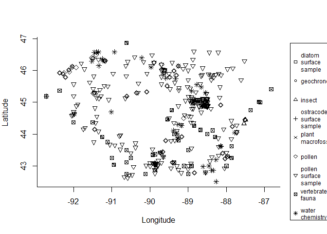

*All Neotoma data points in Wisconsin, with symbols identifying dataset type.*

```r
plot(all_wi)
```

So, we can see the different dataset types. You can pretty much make out Wisconsin, but it doesn’t look that great, and it’s certainly not publication quality. We can make a better map, an interactive map, using leaflet. That’s pretty fun, and the [RStudio help page for `leaflet`](https://rstudio.github.io/leaflet/) is really great to get you started. Make sure the `leaflet` package is installed using `install.packages('leaflet')`, and then let’s check out what we get:

```r
library(leaflet)

# We're going to use this multiple times I think, so let's make it a function:

leaflet_map <- function(dataset_in) {
  dataset_summary <- do.call(rbind, lapply(dataset_in,
                        function(x){
                          # here we pull out the site information from the `dataset` objects:
                          data.frame(name = x$site.data$site.name,
                                     lat  = x$site.data$lat + runif(1, -0.005, 0.005),
                                     long = x$site.data$long + runif(1, -0.005, 0.005),
                                     type = x$dataset.meta$dataset.type)
                        }))

  # The leaflet package documentation uses piping.  For the sake of this tutorial, I won't.
  # First, define a color palette for the dataset type symbol plotting.
  pal <- colorFactor("Dark2", domain = levels(dataset_summary$type))

  # Now make the leaflet map, add base raster tiles and then add the markers for the records:
  map <- leaflet(data = dataset_summary)
  map <- leaflet::addTiles(map)
  map <- leaflet::addCircleMarkers(map, ~long, ~lat,
                                   popup = ~paste0("Site: ", as.character(name), "<br>",
                                                   "Type: ",
                                                   as.character(dataset_summary$type)),
                                   color = ~pal(type),
                                   stroke = FALSE, fillOpacity = 0.5)
  # You need to explicitly call the `map` object to make it appear!
  map
}

# Since that's all wrapped in a function, we can all it with any `dataset_list`:
leaflet_map(all_wi)
```

[interactive chart not shown]

This is much nicer (I think), but it is still missing all the additional information that goes along with a Neotoma record. We can go directly to the Neotoma Explorer using the `browse` function. Unfortunately, because of the limitations of URL string length, this doesn’t always work:

```r
# Does not work:
neotoma::browse(all_wi)

# Does work:
some_wi <- neotoma::get_dataset(gpid = "Wisconsin", datasettype = "pollen")
neotoma::browse(some_wi)
```

Yay! (A browser window should have opened with your datasets in it).

## 2.1 Plotting stratigraphic diagrams

Let’s say we’re looking for all records from Wisconsin with *Larix* pollen, that must have some samples within the middle Holocene:

```r
some_wi <- neotoma::get_dataset(gpid = "Wisconsin", datasettype = "pollen", taxonname = "Larix%", ageyoung = 4000, ageold = 6000)
```

```
## The API call was successful, you have returned 18 records.
```

```r
wi_pollen <- neotoma::get_download(some_wi, verbose = FALSE)
leaflet_map(some_wi) # This is the function we made above.
```

[interactive chart not shown]

What do these records look like?

```r
wi_pollen
```

```
## A download_list containing 18 objects:
## Accessed from 2016-10-13 17:27h to 2016-10-13 17:27h.
## Datasets:
##  dataset.id           site.name      long      lat age.younger age.older
##        3473 Lake Mary           -89.90000 46.25000         200     10345
##         684 Devils Lake         -89.73205 43.41780           0     13614
##         700 Disterhaft Farm Bog -89.16694 43.91694         699     13840
##         860 Gass Lake           -87.73333 44.05000           0     15612
##        1447 Kellys Hollow       -90.35000 45.30000         -29     10000
##        3452 Kellys Hollow       -90.35000 45.30000         -29     10730
##        1448 Kellners Lake       -87.84806 44.23806         -23     14094
##        3781 Stewart's Dark Lake -91.45000 45.30000         482     10649
##        2011 Radtke Lake         -88.10000 43.40000           0     11483
##        3620 Seidel              -87.51556 44.45000          32     11227
##        2624 Tamarack Creek      -91.45000 44.15000           0      4500
##        3035 Wood Lake           -90.08333 45.33333           0     13101
##       15302 Emrick Lake         -89.59428 43.80016         -57     11878
##       15740 Hemlock Lake        -91.19829 46.30730         -42     10877
##       15925 Lake O' Pines       -89.25530 46.14043         -47     12854
##       16129 Lima Bog            -88.84320 42.78895         -31     18406
##       17304 Capitola Lake       -89.55507 45.51958         -40     13288
##       17387 Beaver Lake         -88.15694 44.91960         -30      5103
##    type
##  pollen
##  pollen
##  pollen
##  pollen
##  pollen
##  pollen
##  pollen
##  pollen
##  pollen
##  pollen
##  pollen
##  pollen
##  pollen
##  pollen
##  pollen
##  pollen
##  pollen
##  pollen
```

I like Devil’s Lake, so let’s take a look at the pollen. To get this to work you need the `analogue` package:

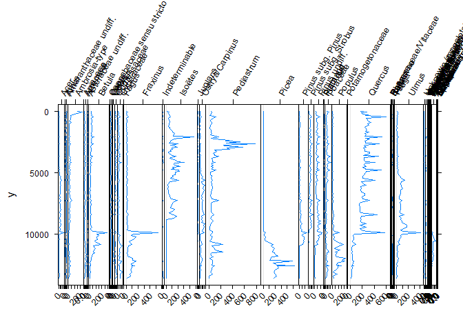

```r
library(analogue, quietly = TRUE)

Stratiplot(wi_pollen[[2]])
```

You have all the advantages of the `Stratiplot()` function now, and the wrapper for the `neotoma` package makes it more useful directly with `download` objects.

## 2.2 Re-building Age-Models

So, I’m interested in the smoothed surface of *Larix* pollen at 4kyr in the region. I’m going to do a lazy job of it, but that’s my perogative. I just want you to see what we might do.

First, we know there are different age types in the records. Let’s see what we’ve got here:

```r
table(sapply(wi_pollen, function(x)x$sample.meta$age.type[1]))
```

```
##
## Calibrated radiocarbon years BP            Radiocarbon years BP
##                               5                              13
```

So, that’s a lot of records to re-do. To do it properly, we need all the chron-controls. When you run this you will get messages letting you know the record has downloaded successfully. I’m suppressing that message here:

```r
wi_chrons <- neotoma::get_chroncontrol(wi_pollen)
```

Now, lets rebuild the model using `Bchrononlogy()` from the `Bchron` package. It helps to know the structure of some of these data objects, so take a bit of time to look at them using the `str()` funciton (for “structure”). Can you understand what I’m passing into the `Bchronology()` function?

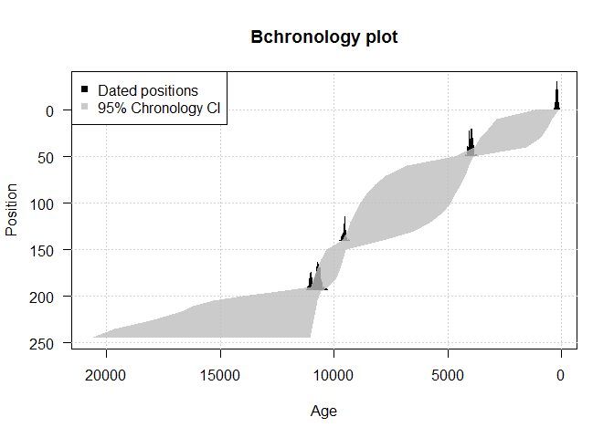

```r
focal <- wi_chrons[[1]]

new_chron <- Bchron::Bchronology(ages   = focal$chron.control$age,
                    ageSds = focal$chron.control$age - focal$chron.control$age.young,
                    positions = focal$chron.control$depth,
                    calCurves = ifelse(focal$chron.control$control.type %in% 'Radiocarbon',
                                       'intcal13', 'normal'),
                    predictPositions = wi_pollen[[1]]$sample.meta$depth)

plot(new_chron)
```

So, you can see that modelling can take a long time, but, we can basically wrap all that logic into a swell little function & run all the models overnight. That was part of my motivation for using the variable `focal` in this code example. Try turning this into a funciton that can work on all of the `download` objects in `wi_pollen`. Does it work?

Wrapping `Bchronology()` around `neotoma`’s `download` objects is something that’s on the TODO list, but there’s a lot of art required to build age models & I’m not sure I want to do that quite yet.

But, let’s just pretend that we’ve done a good job and added all these date into the models. Let’s make a model of the records. I’m using a `gam()` function from the `mgcv` package.

```r
# Running these in sequence gives us a nice narrow dataset, but you should always be aware what
# taxa have been pushed into the Other class for the taxonomies.  The taxonomies in Neotoma itself
# are expanding as datasets get uploaded, but the translation table in this package is only updated
# occasionally.

wi_p25 <- neotoma::compile_taxa(wi_pollen, "P25")
```

[output not shown]

[output cut: 12 more lines]

[output not shown]

[output not shown]

[output cut: 10 more lines]

[output not shown]

[output not shown]

[output cut: 12 more lines]

[output not shown]

[output not shown]

[output not shown]

[output cut: 42 more lines]

[output not shown]

[output not shown]

[output not shown]

[output cut: 70 more lines]

[output not shown]

[output not shown]

[output cut: 18 more lines]

[output not shown]

[output not shown]

[output not shown]

[output cut: 72 more lines]

[output not shown]

[output not shown]

[output not shown]

[output cut: 52 more lines]

[output not shown]

[output not shown]

[output cut: 64 more lines]

[output not shown]

[output not shown]

[output cut: 18 more lines]

[output not shown]

[output not shown]

[output cut: 22 more lines]

[output not shown]

[output not shown]

```r
all_output <- suppressWarnings(neotoma::compile_downloads(wi_p25))

# Convert taxon counts to proportions:
all_output[,11:ncol(all_output)] <- all_output[,11:ncol(all_output)] /
  rowSums(all_output[,11:ncol(all_output)], na.rm = TRUE)

# Combine the
larix_df <- data.frame(lat = all_output$lat,
                       long = all_output$long,
                       age = all_output$age,
                       larix = all_output[,grep("Larix", colnames(all_output))])

lar_model <- mgcv::gam(larix ~ s(lat, long, age), data = larix_df, family = binomial)
```

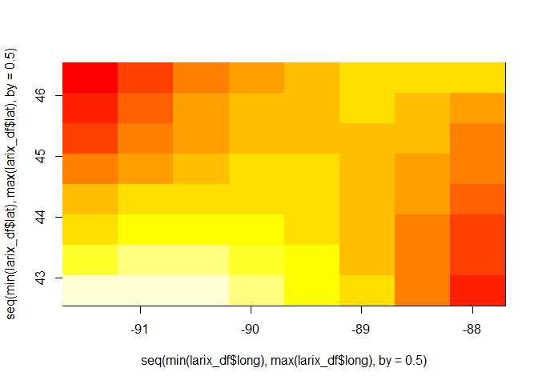

```r
lar_predict <- expand.grid(lat  = seq(min(larix_df$lat),
                                      max(larix_df$lat), by = 0.5),
                           long = seq(min(larix_df$long),
                                      max(larix_df$long), by = 0.5),
                           age  = 4000)

lar_predict$pred <- predict(lar_model, newdata = lar_predict)

image(y = seq(min(larix_df$lat), max(larix_df$lat), by = 0.5),
      x = seq(min(larix_df$long), max(larix_df$long), by = 0.5),
      z = matrix(lar_predict$pred, ncol = length(unique(lar_predict$long))))
points(larix_df[!duplicated(larix_df[,1:2]), 1:2])
```

### 2.2.1 Finding records by Handle

Someties people only publish their records using handles:

```r
data_ca <- get_dataset(datasettype = "pollen", gpid = "Canada")
```

```
## The API call was successful, you have returned 453 records.
```

```r
data_us <- get_dataset(datasettype = "pollen", gpid = "United States")
```

```
## The API call was successful, you have returned 1014 records.
```

```r
datasets <- neotoma::bind(data_ca, data_us)

handles <- sapply(datasets, function(x)x$dataset.meta$collection.handle)

codes <- c("JACKSON","ARRINGTO","BINNEWTR","WOLFCRK","CAMEL","ROCKYHOC","TULANEG","ANDERSON","CLEARPND","QUICKSND","SANDYRUN","WHITEPND","ALEXISLK")

test_datasets <- sapply(codes, function(x)grep(paste0("^", x, "$"), handles))
output <- datasets[test_datasets]
class(output) <- c("dataset_list", "list")

leaflet_map(output)
```

[interactive chart not shown]